# R Notebook

# Guppy omics start

### Downloading the data from Novogene.

```bash
srun -t 24:00:00 -n 8 --mem 60000 --pty /bin/bash
mkdir guppy
cd guppy
mkdir raw
cd raw
wget -r --user="P202SC18122141-01_20181210_AegNaW" --password="lGlLQf" ftp://hwftp.novogene.com/
```

### Downloading genome for *Poecilia reticulata* from NCBI.

```bash
cd ~/guppy/data
mkdir genome
cd genome
wget ftp://ftp.ncbi.nlm.nih.gov/genomes/all/GCF/000/633/615/GCF_000633615.1_Guppy_female_1.0_MT/GCF_000633615.1_Guppy_female_1.0_MT_genomic.fna.gz
```

### Downloading the annotation of that genome.

```bash
wget ftp://ftp.ncbi.nlm.nih.gov/genomes/all/GCF/000/633/615/GCF_000633615.1_Guppy_female_1.0_MT/GCF_000633615.1_Guppy_female_1.0_MT_genomic.gff.gz
```

### Renaming for ease.

```bash
mv GCF_000633615.1_Guppy_female_1.0_MT_genomic.fna.gz preticulata.fna.gz
mv GCF_000633615.1_Guppy_female_1.0_MT_genomic.gff.gz preticulata.gff.gz
```

### Indexing genomes

```bash
zcat preticulata.fna.gz > preticulata.fna
bwa index preticulata.fna
samtools faidx preticulata.fna
```

## Converting sample list to unix

```bash
dos2unix index.txt
```

## Converting names of files with soft link

```bash
#!/bin/bash/
dirs=/home/eoziolor/guppy/data/raw/hwftp.novogene.com/C202SC18122141/raw_data/AWCSU*
my_list=/home/eoziolor/guppy/data/list/index.txt
my_renamed=/home/eoziolor/guppy/data/raw/renamed

for folder in $dirs
do cd $folder
for file in $(ls AWCSU*)
    do
    match=$(echo $file | sed -e "s/AWCSU0[0-9]*_//g" | sed -e "s/_H.*//g")
    new=$(cat $my_list | grep "$match" | awk '{print $2}')
    end=$(echo $file | sed 's/.*\(.......\)/\1/')
    ln -s $folder/$file $my_renamed/$new\_$end
    done
done
```

## Checking on empty files

- We included the empty files as a double check for sequencing success

```bash
dir=/home/eoziolor/guppy/data/raw/renamed
cd $dir
rm ../sizes.txt
touch ../sizes.txt

for file in $(ls *_b_*)
do
    stat -Lc %s $file >> ../sizes.txt
done
```

- And for the true files

```bash
dir=/home/eoziolor/guppy/data/raw/renamed
cd $dir
echo "Real samples" >> ../sizes.txt

for file in $(ls -I "*_b_*")
do
    stat -Lc %s $file >> ../sizes.txt
done
```

- it seems like none of the empty *b* wells has any sample in it. We can remove the soft links to them and proceed.

```bash
dir=/home/eoziolor/guppy/data/raw/renamed
cd $dir
rm *_b_*
```

# QC

## Running FastQC on samples

```bash
#!/bin/bash

#SBATCH -J gp_fastqc
#SBATCH --array=1-384
#SBATCH -e gp_fastqc%A-%a.o
#SBATCH -o gp_fastqc%A-%a.o
#SBATCH -N 1
#SBATCH -n 1
#SBATCH -t 03:00:00
#SBATCH --mem=8000
#SBATCH --no-requeue
#SBASTCH -p med

module load bio3
fastqc --version

#folder
my_dir=/home/eoziolor/guppy/data/raw/renamed
my_out=/home/eoziolor/guppy/data/fastqc/
cd $my_dir

if (($SLURM_ARRAY_TASK_ID < 10))
then
    num=00$(echo $SLURM_ARRAY_TASK_ID)
elif (($SLURM_ARRAY_TASK_ID < 100))
then
    num=0$(echo $SLURM_ARRAY_TASK_ID)
else
    num=$(echo $SLURM_ARRAY_TASK_ID)
fi

echo $num

#code
cd $my_dir
fastqc AWCSU*_$num\_*\.fq.gz \
-o $my_out
```

## Running MultiQC

```bash
module load bio3
conda create --name guppy python=2.7
source activate guppy
conda install -c bioconda multiqc

# run in folder with fastqc files

multiqc .
```

## Manual QC

- Several samples show very low coverage. I want to remove the ones below a certain threshold.

```bash
dir=/home/eoziolor/guppy/data/raw/renamed
cd $dir
touch ../fail_name.txt
touch ../fail_size.txt

for file in $(ls)
do
    echo $file >> ../fail_name.txt
done

for file in $(ls)
do
    stat -Lc %s $file >> ../fail_size.txt
done

paste ../fail_name.txt ../fail_size.txt > ../fails.txt
rm ../fail_name.txt ../fail_size.txt
```

- Choosing to remove files with less than 100 Mb data

```bash
cat ../fails.txt | awk '{OFS="\t"}{if($2<100000000){print $1}}' | xargs rm
```

- Checking that those were removed

```bash
dir=/home/eoziolor/guppy/data/raw/renamed
cd $dir
touch ../fail_name.txt
touch ../fail_size.txt

for file in $(ls)
do
    echo $file >> ../fail_name.txt
done

for file in $(ls)
do
    stat -Lc %s $file >> ../fail_size.txt
done

paste ../fail_name.txt ../fail_size.txt > ../fails_post.txt
rm ../fail_name.txt ../fail_size.txt
```

## Trimming

- Using cutadapt and will do fastqc afterwards.
- Won’t use trimmomatic so that I can use a pipeline with cutadapt after and not have to keep the trimmer reads (if everything went well)

```bash
#!/bin/bash -l

#SBATCH -J trim
#SBATCH --array=1-384
#SBATCH -e trim%A-%a.o
#SBATCH -o trim%A-%a.o
#SBATCH -N 1
#SBATCH -n 8
#SBATCH -t 01-00:00
#SBATCH --mem=8000

module load bio3

#Assigning number to be able to get into each folder separately

if (($SLURM_ARRAY_TASK_ID < 10))
then
    num=00$(echo $SLURM_ARRAY_TASK_ID)
elif (($SLURM_ARRAY_TASK_ID < 100))
then
    num=0$(echo $SLURM_ARRAY_TASK_ID)
else
    num=$(echo $SLURM_ARRAY_TASK_ID)
fi

echo $num

#Directory and file assignment for each file and program
my_dir=/home/eoziolor/guppy/data/raw/renamed
fq1=$my_dir/AWCSU*$num*1.fq.gz
fq2=$my_dir/AWCSU*$num*2.fq.gz
my_bwa=/home/eoziolor/program/bwa-0.7.17/bwa
my_sbl=/home/eoziolor/program/samblaster/samblaster
my_sam=/home/eoziolor/program/samtools-1.9/samtools
my_out=/home/eoziolor/guppy/data/trim/
my_gen=/home/eoziolor/guppy/data/genome/preticulata.fna


#Code
paste <(zcat $fq1 | paste - - - -) \
      <(zcat $fq2 | paste - - - -) |\
tr '\t' '\n' |\
cutadapt -j 8 --interleaved -a CTGTCTCTTATA -A CTGTCTCTTATA -u 10 -U 10 -q 30 --trim-n --minimum-length 36 - | gzip > $my_out/AWCSU.$num.fq.gz
```

## FastQC on trimmed samples

```bash
#!/bin/bash

#SBATCH -J post_fastqc
#SBATCH --array=1-384
#SBATCH -e post_fastqc%A-%a.o
#SBATCH -o post_fastqc%A-%a.o
#SBATCH -N 1
#SBATCH -n 8
#SBATCH -t 1-00:00
#SBATCH --mem=16000
#SBATCH --no-requeue
#SBASTCH -p med

module load bio3
fastqc --version

#folder
my_dir=/home/eoziolor/guppy/data/trim
my_out=/home/eoziolor/guppy/data/fastqc/post
cd $my_dir

if (($SLURM_ARRAY_TASK_ID < 10))
then
    num=00$(echo $SLURM_ARRAY_TASK_ID)
elif (($SLURM_ARRAY_TASK_ID < 100))
then
    num=0$(echo $SLURM_ARRAY_TASK_ID)
else
    num=$(echo $SLURM_ARRAY_TASK_ID)
fi

echo $num

#code
cd $my_dir
fastqc -t 8 AWCSU*\.$num\.fq.gz \
-o $my_out
```

## MultiQC on trimmed samples

```bash
cd ~/guppy/data/fastqc/post/
module load bio3
source activate guppy
multiqc .
cp multiqc_report.html ~/public_html
```

# Mapping

- Creating a sample pop list with column 1 the sample number and column 2 the population beloning

```bash
scp -P 2022 ~/Documents/UCD/Projects/guppy_omics/sample_sheets/pop_assignment.csv farm:~/guppy/data/list/
cd ~/guppy/data/list/

dos2unix pop_assignment.csv

printf "%03d\n" $(cat pop_assignment.csv | tr "," "\t" | awk '{print $1}') > zeros_list.txt

cat pop_assignment.csv | tr ',' '\t' | awk '{OFS=""}{s="\t"}{v="_"}{print $2,v,$3}' > pops.txt

paste zeros_list.txt pops.txt > zeros_pops.txt
```

- Mapping to the reticulata genome

```bash
#!/bin/bash -l

#SBATCH -J guppy_trimalign
#SBATCH --array=1-384
#SBATCH -e guppy_trimalign%A-%a.o
#SBATCH -o guppy_trimalign%A-%a.o
#SBATCH -N 1
#SBATCH -n 8
#SBATCH -t 01-00:00
#SBATCH --mem=16000

module load bio3

#Assigning number to be able to get into each folder separately

if (($SLURM_ARRAY_TASK_ID < 10))
then
    num=00$(echo $SLURM_ARRAY_TASK_ID)
elif (($SLURM_ARRAY_TASK_ID < 100))
then
    num=0$(echo $SLURM_ARRAY_TASK_ID)
else
    num=$(echo $SLURM_ARRAY_TASK_ID)
fi

echo $num

#Assigning new sample numbers with same amount of digits
if (($SLURM_ARRAY_TASK_ID < 10))
then
        sample=00$(echo $SLURM_ARRAY_TASK_ID)
elif (($SLURM_ARRAY_TASK_ID < 100))
then
        sample=0$(echo $SLURM_ARRAY_TASK_ID)
else
        sample=$(echo $SLURM_ARRAY_TASK_ID)
fi


#Directory and file assignment for each file and program
my_dir=/home/eoziolor/guppy/data/raw/renamed
fq1=$my_dir/AWCSU*\_$num\_1.fq.gz
fq2=$my_dir/AWCSU*\_$num\_2.fq.gz
my_bwa=/home/eoziolor/program/bwa-0.7.17/bwa
my_sbl=/home/eoziolor/program/samblaster/samblaster
my_sam=/home/eoziolor/program/samtools-1.9/samtools
my_out=/home/eoziolor/guppy/data/align/
my_gen=/home/eoziolor/guppy/data/genome/preticulata.fna
my_list=/home/eoziolor/guppy/data/list/zeros_pops.txt

#others
pop=$(cat $my_list | grep $sample | cut -f 2)
rg=$(echo \@RG\\tID:$sample\\tPL:Illumina\\tPU:x\\tLB:combined\\tSM:$sample.$pop)
outroot=CSU\_$sample\_$pop

#Code
paste <(zcat $fq1 | paste - - - -) \
      <(zcat $fq2 | paste - - - -) |\
tr '\t' '\n' |\
cutadapt -j 8 --interleaved -a CTGTCTCTTATA -A CTGTCTCTTATA -u 10 -U 10 -q 30 --trim-n --minimum-length 36 - |\
$my_bwa mem $my_gen -p -R $rg -t 2 - |\
$my_sam view -S -h -u - | \
$my_sam sort -T $my_out/$outroot > $my_out/$outroot\.bam
```

- Empty samples were produced because of array parameters. Removing those manually.

```bash
cd ~/guppy/data/align/
rm *_.bam
```

- One issue - created bam files for failed samples! - Let’s remove those

```bash
ls -lS *CSU* | tail -n 27 | awk '{print $9}' > fake_bams.txt

cat fake_bams.txt | xargs rm
```

## Basic mapping statistics

- Using samtools flagstat to look at alignment success

```bash
#!/bin/bash -l

#SBATCH -J flagstat
#SBATCH -e flagstat-%j.o
#SBATCH -o flagstat-%j.o
#SBATCH -N 1
#SBATCH -n 16
#SBATCH -t 01-00:00
#SBATCH --mem=60000
#SBATCH -p high

#files
my_dir=/home/eoziolor/guppy/data/align
my_sam=/home/eoziolor/program/samtools-1.9/bin/samtools
my_out=/home/eoziolor/guppy/data/align/stats.txt

touch $my_out

#code
for file in $my_dir/CSU*.bam; do
    echo $file >> $my_out
    $my_sam flagstat $file >> $my_out
done
```

### Mapping success rate and coverage

```bash
#in folder with bam files
cat stats.txt | grep "mapped (" | awk '{OFS=" "}{print $1}' > mapped_reads.txt
cat stats.txt | grep home | sed 's/\/home\/eoziolor\/guppy\/data\/align\///g' | sed 's/\.bam//g' | tr '_' '\t' | awk '{OFS="\t"}{print $2,$3,$4}' | paste - mapped_reads.txt > mapped_reads_ind.txt
```

### Exploring mapped reads in R

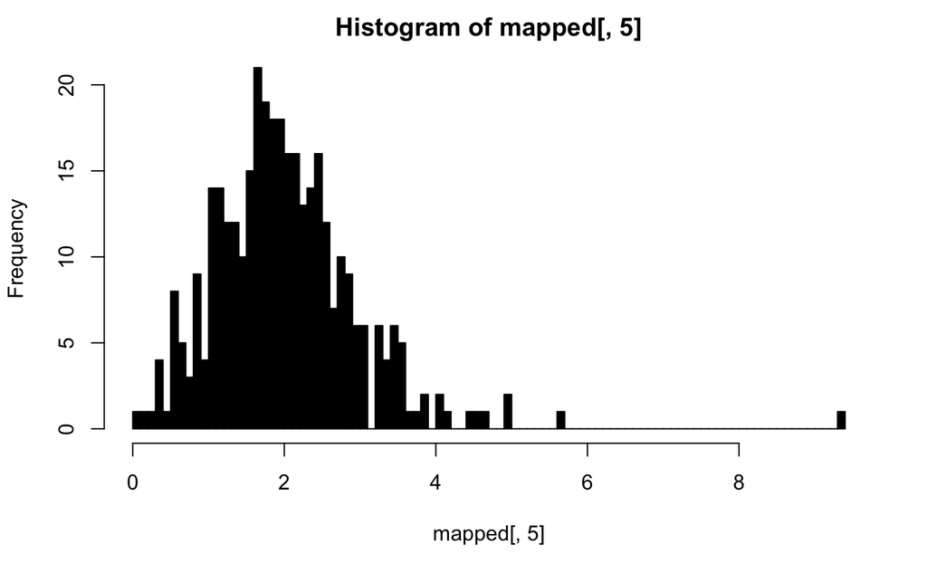

```r
library(ggplot2)
mapped<-read.table("~/guppy/data/mapped_reads_ind.txt",header=F,sep='\t')
mapped<-na.omit(mapped)
#calculating coverage
mapped[,5]<-mapped[,4]*140/830000000
#histogram for overall coverage
hist(mapped[,5],breaks=100, col="black")
```

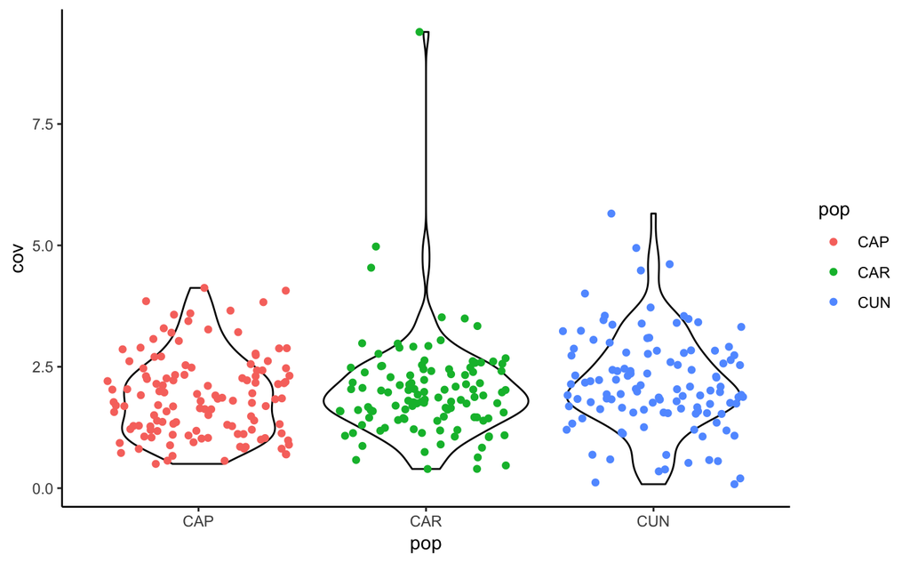

```r
#converting ind to numeric
mapped[,1]<-as.numeric(mapped[,1])
#creating a vector of plate #
for(i in 1:20){
  for(j in 1:(dim(mapped)[1])){
    if(mapped[j,1]<=i*64&&mapped[j,1]>(i-1)*64){
    mapped[j,6]<-i
  }
  }
}
#naming columns
colnames(mapped)<-c("ind","pop","sal","reads","cov","plate")
ggplot(mapped,
       aes(x=pop,y=cov,color=pop))+
  geom_violin(color="black")+
  geom_jitter()+
  theme_classic()
```

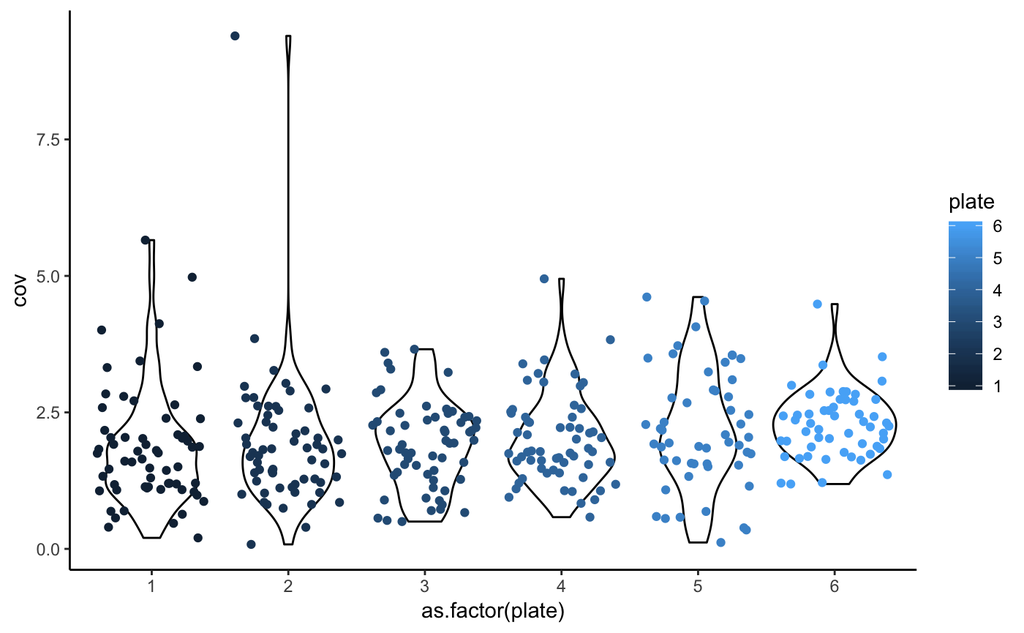

```r
ggplot(mapped,
       aes(x=as.factor(plate),y=cov,color=plate))+
  geom_violin(color="black")+
  geom_jitter()+
  theme_classic()
```

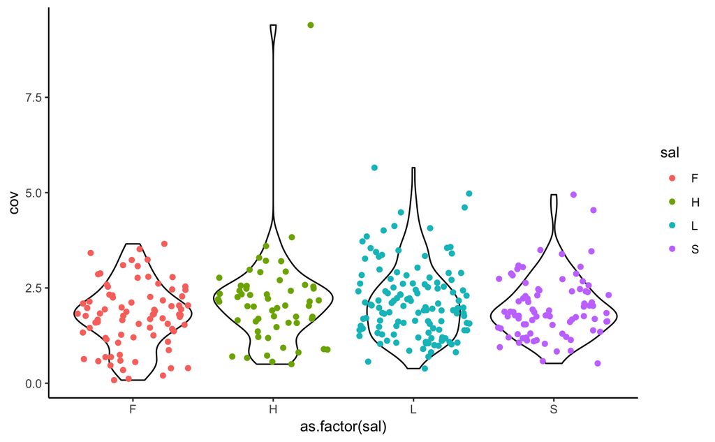

```r
ggplot(mapped,
       aes(x=as.factor(sal),y=cov,color=sal))+
  geom_violin(color="black")+
  geom_jitter()+
  theme_classic()
```

## File with all bam locations

```bash
cd ~/guppy/data/align/
ls -1 CSU* | sed 's/^/\/home\/eoziolor\/guppy\/data\/align\//g' > ~/guppy/data/list/bam_list.txt
```

## Merging all files into one bam

```bash
#!/bin/bash -l

#SBATCH -J mergebam
#SBATCH -e mergebam-%j.o
#SBATCH -o mergebam-%j.o
#SBATCH -N 1
#SBATCH -n 16
#SBATCH -t 02-00:00
#SBATCH --mem=60000
#SBATCH -p high

#files
my_bam=/home/eoziolor/program/bamtools/build/src/toolkit/bamtools
my_merge=/home/eoziolor/guppy/data/align/allmerge.bam
my_list=/home/eoziolor/guppy/data/list/bam_list.txt

#code
$my_bam merge -list $my_list -out $my_merge
```

### Indexing merged_stools.bam file

```bash
#!/bin/bash -l

#SBATCH -J bam_index
#SBATCH -e bam_index-%j.o
#SBATCH -o bam_index%j.o
#SBATCH -N 1
#SBATCH -n 16
#SBATCH -t 01-00:00
#SBATCH --mem=60000
#SBATCH -p high

my_stools=/home/eoziolor/program/samtools-1.9/samtools
my_bam=/home/eoziolor/guppy/data/align/allmerge_stools.bam

$my_stools index -@16 $my_bam
```

### Indexing merged .bam file

```bash
#!/bin/bash -l

#SBATCH -J bam_index
#SBATCH -e bam_index-%j.o
#SBATCH -o bam_index%j.o
#SBATCH -N 1
#SBATCH -n 16
#SBATCH -t 01-00:00
#SBATCH --mem=60000
#SBATCH -p high

my_stools=/home/eoziolor/program/samtools-1.9/samtools
my_bam=/home/eoziolor/guppy/data/align/allmerge_stools.bam

$my_stools index -@16 $my_bam
```

## Indexing individual bam files

```bash
#!/bin/bash -l

#SBATCH -J bam_index
#SBATCH --array=1-383
#SBATCH -e bam_index-%A-%a.o
#SBATCH -o bam_index-%A-%a.o
#SBATCH -N 1
#SBATCH -n 16
#SBATCH -t 01-00:00
#SBATCH --mem=60000
#SBATCH -p high

my_stools=/home/eoziolor/program/samtools-1.9/samtools
my_list=/home/eoziolor/guppy/data/list/bam_list.txt

if (($SLURM_ARRAY_TASK_ID < 10))
then
    num=00$(echo $SLURM_ARRAY_TASK_ID)
elif (($SLURM_ARRAY_TASK_ID < 100))
then
    num=0$(echo $SLURM_ARRAY_TASK_ID)
else
    num=$(echo $SLURM_ARRAY_TASK_ID)
fi

my_sample=$(cat $my_list | grep $num)

echo $num
echo $my_sample

$my_stools index -@ 16 $my_sample
```

# Depth Threshold determination

## Depth per base on merged bam

```bash
#!/bin/bash -l

#SBATCH -J bamdepth
#SBATCH -e bamdepth-%j.o
#SBATCH -o bamdepth-%j.o
#SBATCH -N 1
#SBATCH -n 23
#SBATCH -t 06-00:00
#SBATCH --mem=60000
#SBATCH -p med
#SBATCH --no-requeue

module load bio3

#files
my_list=/home/eoziolor/guppy/data/list/bam_list.txt
my_stools=/home/eoziolor/program/samtools-1.9/bin/samtools
my_out=/home/eoziolor/guppy/data/depth/coverage_allbases.txt.gz
my_dir=/home/eoziolor/guppy/data/align/

#code
$my_stools merge - $my_dir/CSU*.bam | $my_stools depth -d 10000 - | gzip > $my_out
```

## Grabbing 10Mb at random

```bash
#!/bin/bash -l

#SBATCH -J rand10Mb
#SBATCH -e rand10Mb-%j.o
#SBATCH -o rand10Mb-%j.o
#SBATCH -N 1
#SBATCH -n 23
#SBATCH -t 01-00:00
#SBATCH --mem=60000
#SBATCH -p high

module load bio3

#files
dir=/home/eoziolor/guppy/data/depth

zcat $dir/coverage_allbases.txt.gz | \
sort -R | \
head -n 10000000 | \
gzip > $dir/cov_10Mbrand.txt.gz
```

### Observing coverage in R

```r
cov<-read.table("~/guppy/data/cov_10Mbrand.txt.gz",header=F)
names(cov)<-c("chrom","pos","cov")
cov$cov<-as.numeric(cov$cov)
hist(cov$cov,breaks=1000)

subw<-cov$cov<3000
hist(cov[subw,"cov"],breaks=1000)

summary(cov$cov)
summary(cov[subw,"cov"])
```

## High coverage regions

```bash
#!/bin/bash -l

#SBATCH -J highcov
#SBATCH -e highcov-%j.o
#SBATCH -o highcov-%j.o
#SBATCH -N 1
#SBATCH -n 8
#SBATCH -t 03-00:00
#SBATCH --mem=60000
#SBATCH -p high

module load bio3
source ~/.bashrc

#files
my_cov=/home/eoziolor/phpopg/data/depth/coverage_allbases.txt.gz
my_out=/home/eoziolor/phpopg/data/depth/hicov.bed

zcat $my_cov | \
awk '{OFS="\t"}{s=$2-1}{print $1,s,$2,$3}' | \
awk '{OFS="\t"}{if($4>1500){print}}' | \
bedtools merge -i - -d 10 -c 4 -o count > $my_out
```

# Variant calling SNPs

## Freebayes on NC - large autosomes (n=23)

```bash
#!/bin/bash -l

#SBATCH -J bigbayes
#SBATCH --array=1-2300
#SBATCH -e bigbayes%A-%a.o
#SBATCH -o bigbayes%A-%a.o
#SBATCH -t 06-00:00
#SBATCH -n 8
#SBATCH --mem=16G
#SBATCH -p med
#SBATCH --no-requeue

cd /home/eoziolor/guppy/data/varcall/scaffold/

#files
genome=/home/eoziolor/guppy/data/genome/preticulata.fna
my_fai=/home/eoziolor/guppy/data/genome/preticulata.fna.fai
mergebam=/home/eoziolor/guppy/data/align/allmerge_stools.bam
popsfile=/home/eoziolor/guppy/data/list/zeros_pops.txt
hicov=/home/eoziolor/guppy/data/depth/hicov.bed
reg_file=/home/eoziolor/guppy/data/genome/preticulata.fna.genome

#programs
my_freebayes=/home/eoziolor/program/freebayes/bin/freebayes
my_samtools=/home/eoziolor/program/samtools-1.9/samtools
my_bgz=/home/eoziolor/program/htslib/bgzip
my_bedtools=/home/eoziolor/program/bedtools2/bin/bedtools

#selecting scaffold to investigate from the genome file

crap=$(echo $SLURM_ARRAY_TASK_ID)
line=$(echo $(((crap+99)/100)))
scaf=$(sed "$line q;d" $reg_file | cut -f1)
end=$(sed "$line q;d" $reg_file | cut -f2)

#chunking a region to investigate

short=$((end/100))
iter=$((crap-((line-1)*100)))
chunk=$((short*iter))
if [ "$iter" -lt "100" ]; then
    portion=$((1+chunk-short))-$chunk
else
    portion=$((1+chunk-short))-$end
fi
region=$scaf:$portion

echo "This is array number" $crap
echo "I am picking line" $line "from genome file"
echo "It is iteration" $iter "for scaffold" $scaf
echo "The chunk size I am picking is" $short "bases long and this is ending at" $chunk
echo "The region this defines is" $portion "from scaffold with length" $end
echo "\n\n"


#directories and files

outdir=/home/eoziolor/guppy/data/varcall/scaffold
outfile=$scaf\_$iter\.vcf.bgz

$my_samtools view -q 30 -f 2 -h -b  $mergebam $region | \
$my_bedtools intersect -v -a stdin -b $hicov | \
$my_freebayes -f $genome --populations $popsfile --stdin | \
$my_bgz > $outdir/$outfile

echo "The file created is" $outfile
echo "I place it in directory" $outdir
```

## Merging vcf files

```bash
#!/bin/bash -l

#SBATCH -J merge_vcf
#SBATCH -e merge_vcf-%j.o
#SBATCH -o merge_vcf-%j.o
#SBATCH -t 06-00:00
#SBATCH -n 8
#SBATCH --mem=16G
#SBATCH -p high
#SBATCH --no-requeue


my_dir=/home/eoziolor/guppy/data/varcall
my_bgz=/home/eoziolor/program/htslib/bgzip

cd $my_dir/scaffold

zcat NC_024331.1_1.vcf.bgz | grep "#" | $my_bgz > $my_dir/ppicta_merged.vcf.bgz

for i in $(ls -1 | sort --version-sort | head -n 1000); do
zcat $i | grep -v "#" | $my_bgz >> $my_dir/ppicta_merged.vcf.bgz
done
```

## Filtering VCF merge

```bash
#!/bin/bash -l

#SBATCH -J filter_vcf
#SBATCH -e filter_vcf-%j.o
#SBATCH -o filter_vcf-%j.o
#SBATCH -t 06-00:00
#SBATCH -n 8
#SBATCH --mem=16G
#SBATCH -p high
#SBATCH --no-requeue

my_vtools=/home/eoziolor/program/vcftools/bin/vcftools
my_prevcf=/home/eoziolor/guppy/data/varcall/ppicta_merged.vcf.bgz
my_dir=/home/eoziolor/guppy/data/varcall/
my_out=filtered_ppicta
my_bgz=/home/eoziolor/program/htslib/bgzip

cd $my_dir

$my_vtools \
--gzvcf $my_prevcf \
--stdout \
--maf 0.01 \
--min-alleles 2 \
--max-alleles 2 \
--minQ 30 \
--max-missing 0.5 |\
$my_bgz > $my_dir/$my_out.vcf.bgz
```

## Sorting VCF

```bash
my_bgz=/home/eoziolor/program/htslib/bgzip

zcat sample.vcf.bgz | head -n 2829 | $my_bgz > sorted_sample.vcf.bgz
zcat sample.vcf.bgz | grep -v ^"#"| sort -k1,1 -k4,4n | $my_bgz >> sorted_sample.vcf.bgz
```

# WC Fst

## Running Weir and Cockerham Fst

```bash
#!/bin/bash -l

#SBATCH -J wcfst
#SBATCH --array=1-55
#SBATCH -e wcfst%A-%a.o
#SBATCH -o wcfst%A-%a.o
#SBATCH -t 06-00:00
#SBATCH -n 8
#SBATCH --mem=16G
#SBATCH -p med
#SBATCH --no-requeue

outdir=/home/eoziolor/guppy/data/wcfst
popfile=/home/eoziolor/guppy/data/list/zeros_pop.txt
my_wcfst=/home/eoziolor/program/vcflib/bin/wcFst
my_pfst=/home/eoziolor/program/vcflib/bin/pFst
my_vcf=/home/eoziolor/guppy/data/varcall/filtered_ppicta.vcf.bgz
my_bgzip=/home/eoziolor/program/htslib/bgzip

pops=CAP_F\ CAP_H\ CAP_L\ CAP_S\ CAR_F\ CAR_H\ CAR_L\ CAR_S\ CUN_F\ CUN_L\ CUN_S

pair=$(for i in {1..10}
do
    ii=$(expr $i + 1)
    for j in $(seq $ii 11)
    do echo $pops | cut -f $i,$j -d ' '
  done
done | \
sed -n "$(echo $SLURM_ARRAY_TASK_ID)p")

echo $SLURM_ARRAY_TASK_ID

pop1=$(echo $pair | cut -f 1 -d ' ')
pop2=$(echo $pair | cut -f 2 -d ' ')

target=$(grep -n $pop1 $popfile | cut -f 1 -d ":" | awk '{s=$1-1}{print s}' | tr '\n' ',' | \
sed 's/,$//')

background=$(grep -n $pop2 $popfile | cut -f 1 -d ":" | awk '{s=$1-1}{print s}' | tr '\n' ',' | \
sed 's/,$//')

outfile1=$pop1.$pop2.wcfst.bgz
outfile2=$pop1.$pop2.pfst.bgz

out1=$outdir/$outfile1
out2=$outdir/$outfile2

echo $out1
echo $out2

echo $target
echo $background
echo $outfile1
echo $outfile2

$my_wcfst \
--target $target \
--background $background \
--file $my_vcf \
--type GL | \
$my_bgzip>$out1

$my_pfst \
--target $target \
--background $background \
--file $my_vcf \
--type GL | \
$my_bgzip>$out2
```

## Fst to PBS

### TO BE DONE:Converting to windows

```bash
#!/bin/bash -l

#SBATCH -J window_fst
#SBATCH --array=1-55
#SBATCH -e window_fst%A-%a.o
#SBATCH -o window_fst%A-%a.o
#SBATCH -t 06-00:00
#SBATCH -n 8
#SBATCH --mem=16G
#SBATCH -p med
#SBATCH --no-requeue

#program/file
fst_files=/home/eoziolor/guppy/data/wcfst
my_bedtools=/home/eoziolor/program/bedtools2/bin/bedtools
my_genome=/home/eoziolor/guppy/data/genome/preticulata.fna.genome
my_window=/home/eoziolor/guppy/data/window/50kb.10kb.bed

for file in /data/oziolore/fhet/data/fst2/*wcfst.bgz
do
    outfile=$(echo $file | sed 's/wcfst.bgz/fst.1kb.bed/')

    zcat $file | \
    awk '{OFS="\t"}{s=$2-1}{print $1,s,$2,$5}' | \
    $my_bedtools map \
    -a $my_window \
    -b stdin \
    -g $my_genome \
    -c 4,4 \
    -o mean,count> $outfile
done
```

### TO BE DONE: Downloading the data

```bash
scp -P 2022 farm:/home/eoziolor/guppy/data/wcfst/*.bed ~/guppy/data/fst/
```

### TO BE DONE: Converting Fst to PBS

```r
library("RColorBrewer")
library("lattice")
library("gplots")
#Loaidng list of fst files into a list object ----
fs <- list.files("~/guppy/data/fst/", "*fst.1kb.bed",full.names=TRUE)

fst <- list()

for (i in 1:55){
  fst[[i]] <- read.table(fs[i],stringsAsFactors=FALSE)
  fst[[i]][,4] <- as.numeric(fst[[i]][,4])
}

nfs <- gsub(".*\\/","",fs)
nfs <- gsub(".fst.*","",nfs)
names(fst)<-nfs

#loading the pbs function----
pbs <- function(t1,t2,c12){

  t1 <- -log(1-t1)
  t2 <- -log(1-t2)
  c12 <- -log(1-c12)

  stat <- (t1 + t2 - c12)/2
  return(stat)
}

#selecting sites that ahave a minimum representation of 200 snps per region----
nsnps <-fst[[1]][,5]

for (i in 2:55){

  nsnps <- nsnps + fst[[i]][,5]
}

nsnps <- nsnps/55

subw <- nsnps > 200

#calculating FST for all

fstl<-c()
for(i in 1:55){
  fstl[i]<-mean(fst[[i]][subw,4],na.rm=TRUE)
}

names(fstl)<-names(fst)

pops<-c("CAP_F","CAP_H","CAP_L","CAP_S","CAR_F","CAR_H","CAR_L","CAR_S","CUN_F","CUN_L","CUN_S")

fsth<-matrix(nrow = 11,ncol=11) #creating matrix to hold fst data
rownames(fsth)<- pops
colnames(fsth)<- pops

for(i in pops){
  for(j in pops){
    if(i==j){next()}
    fsth[i,j]<-fstl[paste(sort(unique(c(i,j))),collapse=".")]
  }
}

levelplot(fsth,aspect="iso",col.regions=brewer.pal(9,"YlOrRd"),scale=list(x=list(rot=45)),cuts=8)

#Doing pbs on all pops----

pbs_target <- c("CAP_F","CAR_F","CUN_F")
pbs_backgr <- c("CAP_S","CAR_S","CUN_S")

for(i in 1:3){
  for(j in c(i,i+1)){
    if(j==4) j=1 else j=j
    if(j==3) k=1 else k=j+1
    combo<-c(paste(c(pbs_target[i],pbs_backgr[j]),collapse="."),
             paste(c(pbs_target[i],pbs_backgr[k]),collapse="."),
             paste(c(pbs_backgr[j],pbs_backgr[k]),collapse="."))
    print(combo)
  }
}

BBpbs <- pbs(fst[["BB.GB"]][,4],fst[["BB.SP"]][,4],fst[["GB.SP"]][,4])

VBpbs <- pbs(fst[["VB.GB"]][,4],fst[["VB.SP"]][,4],fst[["GB.SP"]][,4])

PBpbs <- pbs(fst[["PB.GB"]][,4],fst[["PB.SP"]][,4],fst[["GB.SP"]][,4])

SJpbs <- pbs(fst[["SJ.GB"]][,4],fst[["SJ.SP"]][,4],fst[["GB.SP"]][,4])

BNPpbs <- pbs(fst[["BNP.GB"]][,4],fst[["BNP.SP"]][,4],fst[["GB.SP"]][,4])


Allpbs <- cbind(
  fst[[1]][,1:3],
  BB = BBpbs,
  VB = VBpbs,
  PB = PBpbs,
  SJ = SJpbs,
  BNP = BNPpbs,
  keep = as.numeric(subw))

write.table(Allpbs,
            file="~/analysis/data/fst/allpbs1kb",
            sep = "\t",
            quote = FALSE,
            row.names = FALSE,
            col.names = FALSE)


plot(BBpbs[subw],pch=20,cex=.5, col=factor(Allpbs[,1]))
quantile(BBpbs[subw],probs=.99,na.rm=TRUE)
abline(h=.1804205)


####Gene comparisons

pbs<-read.table("~/analysis/data/fst/allpbs1kb",header=FALSE)
pbsname<-c("Scaf","start","end","BBpbs","VBpbs","PBpbs","SJpbs","BNPpbs","keep")
colnames(pbs)<-pbsname

col<-c()
for (i in 1:5){
  col[i]<-quantile(pbs[,i+3],prob=.99,na.rm=TRUE)
}

################################################AHR2a

###finding neutral regions to do admixture on----

pbs<-read.table("~/analysis/data/fst/allpbs5kb",header=FALSE)
pbsname<-c("Scaf","start","end","BBpbs","VBpbs","PBpbs","SJpbs","BNPpbs","keep")
colnames(pbs)<-pbsname

npbs<-c()
for (i in 1:1026857){
  npbs[i]<-rowSums((pbs[i,4:8])/5)
}
subw2<-npbs<0.02
subw3<-subw+subw2
subw4<-subw3>1

plot(pbsalt[subw4,4])

pbsalt<- cbind(
  fst[[1]][,1:3],
  BB = BBpbs,
  VB = VBpbs,
  PB = PBpbs,
  SJ = SJpbs,
  BNP = BNPpbs,
  keep=as.numeric(subw4))


write.table(pbsalt,"~/share/fst/pbsneut",
            quote=FALSE,row.names = FALSE,col.names = FALSE,sep='\t')
table(pbsalt[,9])
```

# MDS

```bash
# Using first 5 000 snps to createe a subsample
zcat filtered_ppicta.vcf.bgz | head -n 8000 | $my_bgz > subsample.vcf.bgz

#Downloading
scp -P 2022 farm:/home/eoziolor/guppy/data/varcall/subsample.vcf.bgz ~/guppy/data/

# Haploidizing
zcat < ~/guppy/data/subsample.vcf.bgz | ~/fgfh_post/scripts/haplo/haploidize_gran_mine.r | gzip > ~/guppy/data/subsample_haplo.vcf.gz

# Creating sexscore
cd ~/guppy/data/align/
ls -1 C*.bam | sed 's/CSU\_//g' | sed 's/\.bam//g' | awk '{OFS="\t"}{v="RAND"}{print $1,v}' > ../list/sexscore.txt

#Downloading
scp -P 2022 farm:/home/eoziolor/guppy/data/list/sexscore.txt ~/guppy/data/
```

### Haploidizing function

- I used a script (based on Noah Reid’s script) that haploidizes genotypes based of low coverage data and just pass each file through them. Script below is called haploidize_gran_mine.r

```r
#!/usr/bin/env Rscript

library(stringr)
library(magrittr)

sam<-function(x){
      y <- str_split(x,":")[[1]][1] %>%
                 str_split(.,"\\/") %>%
                 unlist() %>%
                 as.numeric() # pull genotypes
      if(is.na(y)){
        return(".")
      } else {
          z<-str_split(x,":")[[1]][3] %>%
             str_split(.,",") %>%
             unlist() %>%
             as.numeric() # pull allele coverage
          if(y[1]==y[2]){
            h<-y[1]
          } else {
            if(z[1]>z[2]){
              h<-y[1]
            } else {
              h<-sample(y,size=1)
            }
          }
        return(h)
      }
}

f <- file("stdin")
#f<-file("~/analysis/data/dfst/outliers/zshared.vcf.bgz")
open(f)
while(length(line <- readLines(f,n=1)) > 0) {
  if(grepl("^#",line)){write(line,stdout());next()}

  line <- str_split(line,"\\t") %>% unlist()
  line[10:297] <- sapply(line[10:297],sam)
  line <- paste(line,collapse="\t")
  write(line,stdout())
  # write(line, stderr())
  # process line
}
```

## Plotting haplotypes

```r
#install.packages("Rphylip")
library(viridis)
library(dplyr)
library(magrittr)
library(Rphylip)
library(ape)
library(stringr)
vcf<-read.table("~/guppy/data/subsample_haplo.vcf.gz",stringsAsFactors = FALSE) #vcf that has been filtered out to only present one allele call per site per individual
sexscore<-read.table("~/guppy/data/sexscore.txt",header=TRUE)
cname<-c(seq(1:9),as.character(sexscore[,1])) # colnames for the vcf
colnames(vcf)<-cname
#toss sites that happen to have more than one allele
keep<-!grepl(",",vcf[,5]) #none because of the way I've called haplotypes table to check that
gt<-as.matrix(vcf[,10:359])
class(gt)<-"numeric"
```

```
NAs introduced by coercion
```

```r
#toss individuals with greater than 90% missing data
keep<-colMeans(is.na(gt))<0.9
gt<-gt[,keep]
#population identifiers
pop<-ifelse(grepl("CAP_F",sexscore[,1]),"CAP_F",
            ifelse(grepl("CAP_H",sexscore[,1]),"CAP_H",
                   ifelse(grepl("CAP_L",sexscore[,1]),"CAP_L",
                          ifelse(grepl("CAP_S",sexscore[,1]),"CAP_S",
                                 ifelse(grepl("CAR_F",sexscore[,1]),"CAR_F",
                                        ifelse(grepl("CAR_H",sexscore[,1]),"CAR_H",
                                               ifelse(grepl("CAR_L",sexscore[,1]),"CAR_L",
                                                      ifelse(grepl("CAR_S",sexscore[,1]),"CAR_S",
                                                             ifelse(grepl("CUN_F",sexscore[,1]),"CUN_F",
                                                                    ifelse(grepl("CUN_L",sexscore[,1]),"CUN_L",
                                                                           ifelse(grepl("CUN_S",sexscore[,1]),"CUN_S","WRONG")))))))))))
popcol<-ifelse(grepl("CAP_F",sexscore[,1]),"black",
            ifelse(grepl("CAP_H",sexscore[,1]),"black",
                   ifelse(grepl("CAP_L",sexscore[,1]),"black",
                          ifelse(grepl("CAP_S",sexscore[,1]),"black",
                                 ifelse(grepl("CAR_F",sexscore[,1]),"firebrick2",
                                        ifelse(grepl("CAR_H",sexscore[,1]),"firebrick2",
                                               ifelse(grepl("CAR_L",sexscore[,1]),"firebrick2",
                                                      ifelse(grepl("CAR_S",sexscore[,1]),"firebrick2",
                                                             ifelse(grepl("CUN_F",sexscore[,1]),"cadetblue3",
                                                                    ifelse(grepl("CUN_L",sexscore[,1]),"cadetblue3",
                                                                           ifelse(grepl("CUN_S",sexscore[,1]),"cadetblue3","WRONG")))))))))))
popfill<-ifelse(grepl("CAP_F",sexscore[,1]),"black",
            ifelse(grepl("CAP_H",sexscore[,1]),"grey60",
                   ifelse(grepl("CAP_L",sexscore[,1]),"grey30",
                          ifelse(grepl("CAP_S",sexscore[,1]),"grey90",
                                 ifelse(grepl("CAR_F",sexscore[,1]),"firebrick4",
                                        ifelse(grepl("CAR_H",sexscore[,1]),"red",
                                               ifelse(grepl("CAR_L",sexscore[,1]),"firebrick2",
                                                      ifelse(grepl("CAR_S",sexscore[,1]),"lightpink",
                                                             ifelse(grepl("CUN_F",sexscore[,1]),"cadetblue3",
                                                                    ifelse(grepl("CUN_L",sexscore[,1]),"cadetblue3",
                                                                           ifelse(grepl("CUN_S",sexscore[,1]),"cyan","WRONG")))))))))))
pop2<-pop[keep]
popcol2<-popcol[keep]
popfill2<-popfill[keep]
popname<-c("CAP_F","CAP_H","CAP_L","CAP_S","CAR_F","CAR_H","CAR_L","CAR_S","CUN_F","CUN_L","CUN_S")
popnamec<-c("black","black","black","black","firebrick1","firebrick1","firebrick1","firebrick1","cadetblue3","cadetblue3","cadetblue3")
#distance matrix and nj tree
d <- t(gt) %>% dist()
#dd<-as.dist(ultrametric(d)) #imputing data for missing values using ultrametric procedure
mds <- cmdscale(dd)
tr <- nj(dd)
#plotting tree
plot(tr,"unrooted",show.tip.label=FALSE)
tiplabels(pch=20,col=popcol2,bg="white",cex=1.2)
```

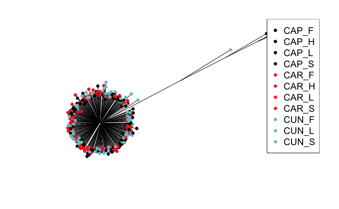

```r
legend("topright",pch=20,cex=1.2,legend=popname,col=popnamec)
#plotting mds
par(mfrow=c(1,1),mar=c(3,3,0,0))
```

```r
plot(mds,col=popcol2,cex=2,cex.axis=2,pch=21,
     bg=popfill2,bty='l')
box(bty='l',lwd=5)
```

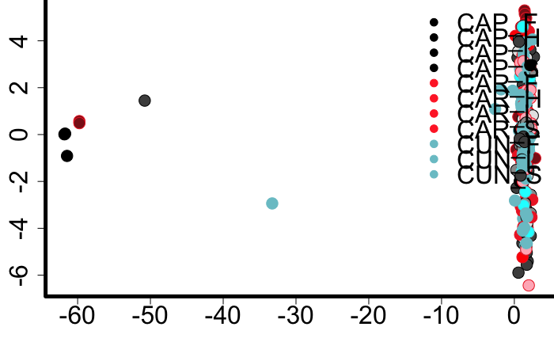

```r
legend("topright",legend=c("CAP_F","CAP_H","CAP_L","CAP_S","CAR_F","CAR_H","CAR_L","CAR_S","CUN_F","CUN_L","CUN_S"),col=c("black","black","black","black","firebrick1","firebrick1","firebrick1","firebrick1","cadetblue3","cadetblue3","cadetblue3"),
       pch=20,cex=2,y.intersp=.5,bty='n')
#Plotting both
par(mfrow=c(1,2))
```

```r
plot(tr,"unrooted",show.tip.label=FALSE)
tiplabels(pch=20,col=popcol2,bg="white",cex=1.2)
```

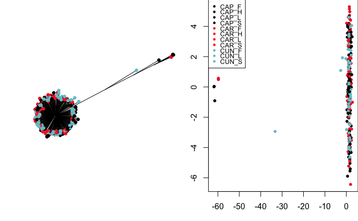

```r
plot(mds,pch=20,col=popcol2)
legend("topleft",pch=20,cex=.8,legend=popname,col=popnamec,y.intersp=.7)
```

# ADMIXTURE

## Running admixture on the data

```bash
#starting by converting vcf to bed file through plink
#!/bin/bash -l

#SBATCH -J vcftobed
#SBATCH -e vcftobed-%j.o
#SBATCH -o vcftobed-%j.o
#SBATCH -t 06-00:00
#SBATCH -n 8
#SBATCH --mem=16G
#SBATCH -p high
#SBATCH --no-requeue

#programs and files
my_plink=/home/eoziolor/program/plink/plink
my_vcf=/home/eoziolor/guppy/data/varcall/filtered_ppicta.vcf.bgz
my_tabix=/home/eoziolor/program/htslib/tabix
my_out=/home/eoziolor/guppy/data/admixture/allscaf

$my_plink \
-vcf $my_vcf \
--allow-extra-chr \
--make-bed \
-out $my_out
```

```bash
#!/bin/bash -l

#SBATCH -J remove-NC
#SBATCH -e remove-NC-%j.o
#SBATCH -o remove-NC-%j.o
#SBATCH -t 06-00:00
#SBATCH -n 8
#SBATCH --mem=16G
#SBATCH -p high
#SBATCH --no-requeue

#files
start_bim=/data/oziolore/fhet/data/admixture/allscaf/allscaf.bim
end_bim=/data/oziolore/fhet/data/admixture/allscaf/allscaf2.bim

cat $start_bim | awk '{gsub("NC_","");print}' > $end_bim
```

```bash
#!/bin/bash -l

#SBATCH -J kdetermine
#SBATCH -e kdetermine-%j.o
#SBATCH -o kdetermine-%j.o
#SBATCH -t 06-00:00
#SBATCH -n 16
#SBATCH --mem=32G
#SBATCH -p high
#SBATCH --no-requeue

#programs
admix=/home/eoziolor/program/admixture/admixture
allscaf=/home/eoziolor/guppy/data/admixture/allscaf.bed
out=/home/eoziolor/guppy/data/admixture/allscaf

$admix --cv -j16 $allscaf $PBS_ARRAY_INDEX | tee $out/log${PBS_ARRAY_INDEX}.out
```

### Plotting admixture proportions

```r
ord_temp<-read.table("~/analysis/data/admixture/seqlist.txt",header=FALSE)
ord<-unlist(ord_temp)

k2<-read.table("~/analysis/data/admixture/all/allscaf.2.Q")
k2ord<-k2[ord,]
barplot(t(as.matrix(k2ord)),col=c("deepskyblue2","black"), ylab="Ancestry",border=NA, xaxt="n",space=0,
        cex.lab=1.5,cex.axis=1.5)

abline(b=0,v=c(0,48,96,144,168,215,264,288),col="grey",lwd=3,lty=5)
abline(a=0,b=0,col="black",lwd=3)

ax<-c(24,72,124,156,192,240,276)
axnames<-c("SP","GB","BNP", "SJ","PB","VB","BB")
axis(side=1,at= ax, labels = axnames,tck=-.03)

gb<-k2ord[0:48,]
gbord<-order(gb[,2],decreasing=TRUE)

sp<-k2ord[49:96,]
spord<-order(sp[,2],decreasing=TRUE)

bnp<-k2ord[97:144,]
bnpord<-order(bnp[,2],decreasing=TRUE)

sj<-k2ord[145:168,]
sjord<-order(sj[,2],decreasing=TRUE)

pb<-k2ord[168:215,]
pbord<-order(pb[,2],decreasing=TRUE)

vb<-k2ord[215:264,]
vbord<-order(vb[,2],decreasing=TRUE)

bb<-k2ord[265:288,]
bbord<-order(bb[,2],decreasing=TRUE)

kall<-rbind(bb[bbord,],vb[vbord,],pb[pbord,],sj[sjord,],bnp[bnpord,],gb[gbord,],sp[spord,])

kall<-na.omit(kall)

par(mfrow=c(1,1),mar=c(3,3,1,1))
barplot(t(as.matrix(kall)),col=c("cadetblue2","black"), border=NA, xaxt="n",space=0,
        cex.lab=2,cex.axis=1.9)

ax<-c(12,48,96,132,168,216,264)
ax2<-c(0,121,122,193,194,288)
vert<-c(24,74,122,146,194,242)
axnames<-c("BB","VB","PB", "SJ","BNP","SP","GB")
axcol<-c("black","firebrick2","cadetblue3")
axis(side=1,at= ax[1:3], labels = axnames[1:3],tck=-.02,lwd=0,
     col.axis=axcol[1],col=axcol[1],cex.axis=1.6)
axis(side=1,at= ax[4:5], labels = axnames[4:5],tck=-.02,lwd=0,
     col.axis=axcol[2],col=axcol[2],cex.axis=1.6)
axis(side=1,at= ax[6:7], labels = axnames[6:7],tck=-.02,lwd=0,
     col.axis=axcol[3],col=axcol[3],cex.axis=1.6)
#Just the lines
axis(side=1,at= ax2[1:2], labels=c("",""), tck=0,lwd=4,
     col.axis=axcol[1],col=axcol[1],cex.axis=1.4)
axis(side=1,at= ax2[3:4], labels = c("",""),tck=0,lwd=4,
     col.axis=axcol[2],col=axcol[2],cex.axis=1.4)
axis(side=1,at= ax2[5:6], labels = c("",""),tck=-0,lwd=4,
     col.axis=axcol[3],col=axcol[3],cex.axis=1.4)
abline(v=vert,col="khaki2",lty=1,lwd=2.5)

########################################################
k3<-read.table("~/analysis/data/admixture/all/allscaf.3.Q")
k3ord<-k3[ord,]
barplot(t(as.matrix(k3ord)),col=c("black","deepskyblue2","red"), ylab="Ancestry",border=NA, xaxt="n",space=0)

abline(b=0,v=c(0,48,96,144,168,215,264,288),col="grey",lwd=3,lty=5)

ax<-c(24,72,124,156,192,240,276)
axnames<-c("SP","GB","BNP", "SJ","PB","VB","BB")
axis(side=1,at= ax, labels = axnames,tck=-.03)

##########################################################
k4<-read.table("~/analysis/data/admixture/all/allscaf.4.Q")
k4ord<-k4[ord,]

gb<-k4ord[0:48,]
gbord<-order(gb[,2],decreasing=TRUE)

sp<-k4ord[49:96,]
spord<-order(sp[,2],decreasing=TRUE)

bnp<-k4ord[97:144,]
bnpord<-order(bnp[,3],decreasing=TRUE)

sj<-k4ord[145:168,]
sjord<-order(sj[,3],decreasing=TRUE)

pb<-k4ord[168:215,]
pbord<-order(pb[,3],decreasing=TRUE)

vb<-k4ord[215:264,]
vbord<-order(vb[,3],decreasing=TRUE)

bb<-k4ord[265:288,]
bbord<-order(bb[,3],decreasing=TRUE)

kall<-rbind(bb[bbord,],vb[vbord,],pb[pbord,],sj[sjord,],bnp[bnpord,],gb[gbord,],sp[spord,])

kall<-na.omit(kall)
barplot(t(as.matrix(kall)),col=c("red","deepskyblue2","black","darkorange"), ylab="Ancestry",border=NA, xaxt="n",space=0,
        cex.lab=1.5,cex.axis = 1.5)

ax<-c(12,48,96,132,168,216,264)
ax2<-c(0,121,122,193,194,288)
vert<-c(24,74,122,146,194,242)
axnames<-c("BB","VB","PB", "SJ","BNP","SP","GB")
axcol<-c("black","firebrick2","cadetblue3")
axis(side=1,at= ax[1:3], labels = axnames[1:3],tck=-.02,lwd=0,
     col.axis=axcol[1],col=axcol[1],cex.axis=1.6)
axis(side=1,at= ax[4:5], labels = axnames[4:5],tck=-.02,lwd=0,
     col.axis=axcol[2],col=axcol[2],cex.axis=1.6)
axis(side=1,at= ax[6:7], labels = axnames[6:7],tck=-.02,lwd=0,
     col.axis=axcol[3],col=axcol[3],cex.axis=1.6)
#Just the lines
axis(side=1,at= ax2[1:2], labels=c("",""), tck=0,lwd=4,
     col.axis=axcol[1],col=axcol[1],cex.axis=1.4)
axis(side=1,at= ax2[3:4], labels = c("",""),tck=0,lwd=4,
     col.axis=axcol[2],col=axcol[2],cex.axis=1.4)
axis(side=1,at= ax2[5:6], labels = c("",""),tck=-0,lwd=4,
     col.axis=axcol[3],col=axcol[3],cex.axis=1.4)
abline(v=vert,col="khaki2",lty=1,lwd=2.5)
```

# ANGSD

## Lists of population samples

- For angsd to run on populations, we need to create list of each population.

```bash
cd /home/eoziolor/guppy/data/list
mkdir pops
cat pops.txt | sort |  uniq > uniq.popx.txt

for pop in $(cat uniq.pops.txt)
do
cat bam_list.txt | grep $pop > pops/$pop.txt
done

cd pops
for i in $(ls C*); do echo $i; cat $i | wc -l; done > sample_sizes.txt
```

## High coverage applying filter

- applying filter for high coverage sites to genome file in order to only keep normal coverage ones

```bash
#Downloading data to look at how much of the genome I threw out
mkdir ~/guppy/data/angsd
scp -P 2022 farm:/home/eoziolor/guppy/data/depth/hicov.bed ~/guppy/data/angsd/
```

## Looking at size of excluded high coverage regions

```r
hi<-read.table("~/guppy/data/angsd/hicov.bed",header=FALSE)
sum(hi[,4])

#Threw out 14Mb of data => 1.6% of the genome
```

## Creating a keepsites file

```bash
#[cluster]
#!/bin/bash -l

#SBATCH -J keepsites
#SBATCH -e keepsites-%j.o
#SBATCH -o keepsites-%j.o
#SBATCH -N 1
#SBATCH -n 8
#SBATCH -t 03-00:00
#SBATCH --mem=60000
#SBATCH -p high

module load bio3
source ~/.bashrc

my_cov=/home/eoziolor/guppy/data/depth/coverage_allbases.txt.gz
my_out=/home/eoziolor/guppy/data/angsd/keepsites.bed

zcat $my_cov | \
awk '{OFS="\t"}{s=$2-1}{print $1,s,$2,$3}' | \
awk '{OFS="\t"}{if($4<1500){print}}' | \
bedtools merge -i - -d 10 > $my_out
```

- Converting those to a .file format for ANGSD to deal with

```bash
cat /home/eoziolor/guppy/data/angsd/keepsites.bed | \
awk '{OFS="\t"}{s=$2+1}{print $1,s,$3}' > /home/eoziolor/guppy/data/angsd/keepsites.file
```

- Downloading the .bed file to make a script with 50Mb randomly selected to create expectation for SFS

```bash
scp -P 2022 farm:/home/eoziolor/guppy/data/angsd/keepsites.bed ~/guppy/data/angsd/
```

- Script to pick up 50Mb at random from the keepsites file in order to run SAF and SFS on those for bayesian priors

```r
orig<-read.table("~/guppy/data/angsd/keepsites.bed", header=F) #reading in the keepsites file

p<-(orig[,3]-orig[,2])/(sum(orig[,3]-orig[,2])) #creating probability vector so that I don't oversample large chunks

p<-unlist(p) #unlisting the vector

z<-p<0 #removing any negative probabilities for 0 values
p<-p[!z] #applying that to vector

v<-sample(x=length(p),size=2650,prob=p) #sampling 2650 chunks with probability to get out ~50Mb of the genome
v<-sort(v)
sum(orig[v,3]-orig[v,2]) #checking the total size of bases

write.table(orig[v,], file="~/guppy/data/angsd/keep50Mb.bed",row.names=FALSE,col.names=FALSE,quote=FALSE, sep='\t')
```

- putting that data back into [cluster]

```bash
scp -P 2022 ~/guppy/data/angsd/keep50Mb.bed farm:/home/eoziolor/guppy/data/angsd/
```

- Converting that to a .file

```bash
cat /home/eoziolor/guppy/data/angsd/keep50Mb.bed | \
awk '{OFS="\t"}{s=$2+1}{print $1,s,$3}' > /home/eoziolor/guppy/data/angsd/keep50Mb.file

cat /home/eoziolor/guppy/data/angsd/keepsites.bed | \
awk '{OFS="\t"}{s=$2+1}{print $1,s,$3}' > /home/eoziolor/guppy/data/angsd/keepsites.file
```

- indexing all of those files with ANGSD

```bash
/home/eoziolor/program/angsd/angsd sites index /home/eoziolor/guppy/data/angsd/keepsites.file
/home/eoziolor/program/angsd/angsd sites index /home/eoziolor/guppy/data/angsd/keep50Mb.file
```

## SAF (Site Allele Frequency) estimate

- Starting site allele frequency estimation on a 50Mb subsample for each population (to create SFS)

```bash
#!/bin/bash -l

#SBATCH -J saf_50mb
#SBATCH --array=1-11
#SBATCH -e saf_50mb%A-%a.o
#SBATCH -o saf_50mb%A-%a.o
#SBATCH -t 06-00:00
#SBATCH -n 8
#SBATCH --mem=16G
#SBATCH -p med
#SBATCH --no-requeue

pops=CAP_F\ CAP_H\ CAP_L\ CAP_S\ CAR_F\ CAR_H\ CAR_L\ CAR_S\ CUN_F\ CUN_L\ CUN_S

one=$(echo $pops | cut -f $SLURM_ARRAY_TASK_ID -d ' ')

#files
list=/home/eoziolor/guppy/data/list/pops/$one\.txt
genome=/home/eoziolor/guppy/data/genome/preticulata.fna
keep=/home/eoziolor/guppy/data/angsd/keep50Mb.file
outfile=/home/eoziolor/guppy/data/angsd/$one\_small
my_angsd=/home/eoziolor/program/angsd/angsd

$my_angsd \
-bam $list \
-doSaf 1 \
-fold 1 \
-anc $genome \
-GL 2 \
-minMapQ 30 \
-minQ 20 \
-minind 10 \
-sites $keep \
-out $outfile
```

## SFS (Site Frequency Spectra)

- Using the subsampled .saf to create site frequency spectra

```bash
#!/bin/bash -l

#SBATCH -J sfs
#SBATCH --array=1-11
#SBATCH -e sfs%A-%a.o
#SBATCH -o sfs%A-%a.o
#SBATCH -t 06-00:00
#SBATCH -n 8
#SBATCH --mem=16G
#SBATCH -p med
#SBATCH --no-requeue

pops=CAP_F\ CAP_H\ CAP_L\ CAP_S\ CAR_F\ CAR_H\ CAR_L\ CAR_S\ CUN_F\ CUN_L\ CUN_S

one=$(echo $pops | cut -f $SLURM_ARRAY_TASK_ID -d ' ')


#program and file
my_sfs=/home/eoziolor/program/angsd/misc/realSFS
in_saf=/home/eoziolor/guppy/data/angsd/$one\_small.saf.idx
outdir=/home/eoziolor/guppy/data/angsd
out_sfs=$one\.sfs

#code

$my_sfs $in_saf -maxIter 100 -P 8 -nSites 50000000 > $outdir/$out_sfs
```

### SFS download for R

- Once saf and sfs are created, take sfs to R to look at distribution

```bash
scp -P 2022 farm:/home/eoziolor/guppy/data/angsd/*.sfs ~/guppy/data/angsd/
```

### Plot SFS in R

```r
sf<-list.files("~/guppy/data/angsd/","*.sfs",full.names=TRUE)
cols<-c(rep("black",4),rep("red",4),rep("blue",4))
pop<-list("CAP_F","CAP_H","CAP_L","CAP_S","CAR_F","CAR_H","CAR_L","CAR_S","CUN_F","CUN_L","CUN_S")
#pop<-list("CAP_F","CAP_H","CAP_S","CAR_F","CUN_F","CUN_S")

for(i in 1:11){
  pop[[i]]<-scan(sf[[i]])
}

par(mfrow=c(3,4),mar=c(2,2,2,2))
for(i in 1:11){
  plot(log(pop[[i]]),col="black",pch=20,lwd=3)
}
```

## Thetas per site

- new script

```bash
#!/bin/bash -l

#SBATCH -J thetas
#SBATCH --array=1-11
#SBATCH -e thetas%A-%a.o
#SBATCH -o thetas%A-%a.o
#SBATCH -t 06-00:00
#SBATCH -n 8
#SBATCH --mem=16G
#SBATCH -p med
#SBATCH --no-requeue

pops=CAP_F\ CAP_H\ CAP_L\ CAP_S\ CAR_F\ CAR_H\ CAR_L\ CAR_S\ CUN_F\ CUN_L\ CUN_S

one=$(echo $pops | cut -f $SLURM_ARRAY_TASK_ID -d ' ')

#files
list=/home/eoziolor/guppy/data/list/pops/$one\.txt
genome=/home/eoziolor/guppy/data/genome/preticulata.fna
keep=/home/eoziolor/guppy/data/angsd/keepsites.file
outfile=/home/eoziolor/guppy/data/angsd/$one\_theta
my_angsd=/home/eoziolor/program/angsd/angsd
my_sfs=/home/eoziolor/guppy/data/angsd/$one\.sfs

#Code
$my_angsd \
-bam $list \
-out $outfile \
-doThetas 1 \
-fold 1 \
-doSaf 1 \
-pest  $my_sfs \
-anc $genome \
-sites $keep \
-minMapQ 30 \
-minQ 20 \
-minind 10 \
-GL 2
```

### Converting readable thetas.gz

- Reading thetas.gz file to a readable state: below is command for folded estimate of subsample

```bash
#!/bin/bash -l

#SBATCH -J convert_thetas
#SBATCH --array=1-11
#SBATCH -e convert_thetas%A-%a.o
#SBATCH -o convert_thetas%A-%a.o
#SBATCH -t 06-00:00
#SBATCH -n 8
#SBATCH --mem=16G
#SBATCH -p med
#SBATCH --no-requeue

pops=CAP_F\ CAP_H\ CAP_L\ CAP_S\ CAR_F\ CAR_H\ CAR_L\ CAR_S\ CUN_F\ CUN_L\ CUN_S

one=$(echo $pops | cut -f $SLURM_ARRAY_TASK_ID -d ' ')


#program/file
my_stat=/home/eoziolor/program/angsd/misc/thetaStat
file=/home/eoziolor/guppy/data/angsd/$one\.theta.thetas.idx
out=/home/eoziolor/guppy/data/angsd/$one\_readable_theta.gz

$my_stat print $file | gzip > $out
```

### Breaking them into sliding windows

```bash
#!/bin/bash -l

#SBATCH -J window_thetas
#SBATCH --array=1-11
#SBATCH -e window_thetas%A-%a.o
#SBATCH -o window_thetas%A-%a.o
#SBATCH -t 06-00:00
#SBATCH -n 8
#SBATCH --mem=16G
#SBATCH -p med
#SBATCH --no-requeue

pops=CAP_F\ CAP_H\ CAP_L\ CAP_S\ CAR_F\ CAR_H\ CAR_L\ CAR_S\ CUN_F\ CUN_L\ CUN_S

one=$(echo $pops | cut -f $SLURM_ARRAY_TASK_ID -d ' ')

#programs and files

my_bedtools=/home/eoziolor/program/bedtools2/bin/bedtools
thetas=/home/eoziolor/guppy/data/angsd/theta/$one\_readable_theta.gz
window=/home/eoziolor/guppy/data/window/50kb.10kb.bed
my_genome=/home/eoziolor/guppy/data/genome/preticulata.fna.fai
outdir=/home/eoziolor/guppy/data/angsd/theta
outfile=$one\_neut_1kb.bed

zcat $thetas | \
egrep -v "^#" | \
awk '{OFS="\t"}{w=exp($3)}{pi=exp($4)}{s=$2-1}{print $1,s,$2,w,pi}' | \
$my_bedtools map \
-a $window \
-b stdin \
-g <(cut -f 1-2 $my_genome) \
-c 4,4,5,5 \
-o sum,count,sum,count > $outdir/$outfile
```

## Plotting distribution of neutral estimates

```bash
scp -P 2022 farm:/home/eoziolor/guppy/data/angsd/*50kb* ~/guppy/data/angsd/
```

## Tajima’s D

- Break the file into pi, theta and and calculate tajima’s D, starting with 50kb windows for speed

```r
### Loading pi(column6), theta(column4), and counts(columns 5,7)

CAP_F<-read.table("~/guppy/data/angsd/CAP_F_neut_50kb.bed",stringsAsFactors=FALSE) #reading in all files
CAP_H<-read.table("~/guppy/data/angsd/CAP_H_neut_50kb.bed",stringsAsFactors=FALSE)
CAP_L<-read.table("~/guppy/data/angsd/CAP_L_neut_50kb.bed",stringsAsFactors=FALSE)
CAP_S<-read.table("~/guppy/data/angsd/CAP_S_neut_50kb.bed",stringsAsFactors=FALSE)
CAR_F<-read.table("~/guppy/data/angsd/CAR_F_neut_50kb.bed",stringsAsFactors=FALSE)
CAR_H<-read.table("~/guppy/data/angsd/CAR_H_neut_50kb.bed",stringsAsFactors=FALSE)
CAR_L<-read.table("~/guppy/data/angsd/CAR_L_neut_50kb.bed",stringsAsFactors=FALSE)
CAR_S<-read.table("~/guppy/data/angsd/CAR_S_neut_50kb.bed",stringsAsFactors=FALSE)
CUN_F<-read.table("~/guppy/data/angsd/CUN_F_neut_50kb.bed",stringsAsFactors=FALSE)
CUN_L<-read.table("~/guppy/data/angsd/CUN_L_neut_50kb.bed",stringsAsFactors=FALSE)
CUN_S<-read.table("~/guppy/data/angsd/CUN_S_neut_50kb.bed",stringsAsFactors=FALSE)

colnam<-c("scaf","Start","End","Theta","Tcount","Pi","Pcount") #giving them column names
colnames(CAP_F)<-colnam
colnames(CAP_H)<-colnam
colnames(CAP_L)<-colnam
colnames(CAP_S)<-colnam
colnames(CAR_F)<-colnam
colnames(CAR_H)<-colnam
colnames(CAR_L)<-colnam
colnames(CAR_S)<-colnam
colnames(CUN_F)<-colnam
colnames(CUN_L)<-colnam
colnames(CUN_S)<-colnam

pops<-list(CAP_F,CAP_H,CAP_L,CAP_S,CAR_F,CAR_H,CAR_L,CAR_S,CUN_F,CUN_L,CUN_S)
popnames<-c("CAP_F","CAP_H","CAP_L","CAP_S","CAR_F","CAR_H","CAR_L","CAR_S","CUN_F","CUN_L","CUN_S")
names(pops)<-popnames

for(i in popnames){ #reading in the files as.numeric
  for(j in 4:7){
    pops[[i]][,j]<-as.numeric(pops[[i]][,j])
  }
}

cov<-cbind(CAR_F[1:3],CAP_F[,7],CAP_H[,7],CAP_L[,7],CAP_S[,7],CAR_F[,7],CAR_H[,7],
           CAR_L[,7],CAR_S[,7],CUN_F[,7],CUN_L[,7],CUN_S[,7]) #creating a vector of coverage of each statistic call

nsnps<-cov[,4] #creating a vector that sums all calls over each SNP
for (i in 5:14){
  nsnps <- nsnps + cov[,i]
}
nsnps <- nsnps/11 #dividing by number of populations and only using sites that have at least 20 SNPS used over the window per population

subw <- nsnps > 1000 #filter to be saved for these windows


#calculating mean and median pi----
pimean<-c() #calculating mean
for(i in popnames){
  pimean[i]<-sum(pops[[i]][subw,6],na.rm=TRUE)/sum(pops[[i]][subw,7],na.rm=TRUE)
}

#converting these to per base estimates
popbase<-list()

for(i in popnames){ #calculating per base estimates rather than averaged estimates over the windows we have
  popbase[[i]]<-cbind(pops[[i]][,1:3],pops[[i]][,4]/pops[[i]][,5],pops[[i]][,6]/pops[[i]][,7])
}

names<-c("scaf", "start","end",'theta/b',"pi/b")

for(i in popnames){ #giving the new list column names
  colnames(popbase[[i]])<-names
}

wt<-matrix(nrow=length(popbase[[1]][,1]),ncol=length(popnames)) #making a matrix of Waterson's theta values
for(i in 1:11){
  wt[,i]<-popbase[[i]][,4]
}
colnames(wt)<-popnames

pi<-matrix(nrow=length(popbase[[1]][,1]),ncol=length(popnames)) #making a matrix of pi values
for(i in 1:11){
  pi[,i]<-popbase[[i]][,5]
}
colnames(pi)<-popnames


source("~/fgfh_post/scripts/angsd/tajimas.r")

taj<-list()

popsize<-c(16,32,51,23,28,26,32,28,38,44,32)

for(i in popnames){ #calculating tajima's D for all populations through a function in r; takes forever
  print(i)
  for(j in 1:dim(pi)[[1]]){
    taj[[i]]<-c(taj[[i]],tajimas(pi[j,i],wt[j,i],popsize[match(i,popnames)]))
  }
}


###

taj<-cbind(popbase[[1]][,1:3],taj[["CAP_F"]],taj[["CAP_H"]],taj[["CAP_L"]],taj[["CAP_S"]],taj[["CAR_F"]],taj[["CAR_H"]],taj[["CAR_L"]],taj[["CAR_S"]],taj[["CUN_F"]],taj[["CUN_L"]],taj[["CUN_S"]]) #binding into a dataframe

taj<-cbind(taj,keep=as.numeric(subw)) #keeping the filter of low representation bases

tajname<-c("scaf","start","end","CAP_F","CAP_H","CAP_L","CAP_S","CAR_F","CAR_H","CAR_L","CAR_S","CUN_F","CUN_L","CUN_S","keep") #column names
colnames(taj)<-tajname

write.csv(taj,file="~/guppy/data/angsd/taj",quote=FALSE,row.names=FALSE) #writing tajima's d

theta<-cbind(popbase[["CAP_F"]][1:3],wt,keep=as.numeric(subw))

thetname<-c("scaf","start","end","CAP_F","CAP_H","CAP_L","CAP_S","CAR_F","CAR_H","CAR_L","CAR_S","CUN_F","CUN_L","CUN_S","keep")
colnames(theta)<-thetname

write.csv(theta,file="~/guppy/data/angsd/thetas",quote=FALSE,row.names=FALSE)


pi<-cbind(popbase[["CAP_F"]][1:3],pi,keep=as.numeric(subw))

piname<-c("scaf","start","end","CAP_F","CAP_H","CAP_L","CAP_S","CAR_F","CAR_H","CAR_L","CAR_S","CUN_F","CUN_L","CUN_S","keep")
colnames(pi)<-piname
write.csv(pi,file="~/guppy/data/angsd/pi",quote=FALSE,row.names=FALSE)

write.csv(cov,file="~/guppy/data/angsd/cov",quote=FALSE,row.names = FALSE)
```

## Plotting pi and Taj’s D

```r
library('tidyr')
library('tibble')
library('magrittr')
library('dplyr')
library('gridExtra')

#loading neutrality stats----

theta<-read.table("~/guppy/data/angsd/thetas",header=TRUE, sep=',') #reading in summary statistics
pi<-read.table("~/guppy/data/angsd/pi", header=TRUE, sep=',')
taj<-read.table("~/guppy/data/angsd/taj",header=TRUE, sep=',')

subw<-pi[,"keep"]>0 #applying filter of low coverage

##ggplot pi----
library(ggplot2)
library(reshape2)

mpi<-melt(pi[subw,1:14],id=c("scaf","start","end"))

jpeg(filename="~/guppy/data/angsd/pi.jpg",width=1000,height=600)
ggplot(mpi,
       aes(x=variable,y=value,fill=variable,color=variable))+
  geom_violin(trim=FALSE,draw_quantiles = 0.5,lwd=2)+
  scale_fill_manual(values=c("black","grey30","grey60","grey90","firebrick4","firebrick2","lightpink3", "lightpink1","cadetblue3","cadetblue1","cyan"))+
  scale_color_manual(values=c("grey40",rep("black",10)))+
  scale_y_continuous(limits=c(0.001,.04))+
  theme_classic()+
  labs(y="",x="")+
  theme(axis.line.y=element_line(color="black",size=5),axis.line=element_line(color="black",size=5))+
  theme(axis.text.y=element_text(color="black",size=40))+
  theme(axis.text.x=element_text(color="black",size=20,angle=90))
dev.off()

mtaj<-melt(taj[subw,1:14],id=c("scaf","start","end"))

jpeg(filename="~/guppy/data/angsd/taj.jpg",width=1000,height=600)
ggplot(mtaj,
       aes(x=variable,y=value,fill=variable,color=variable))+
  geom_violin(trim=FALSE,draw_quantiles = 0.5,lwd=2)+
  scale_fill_manual(values=c("black","grey30","grey60","grey90","firebrick4","firebrick2","lightpink3", "lightpink1","cadetblue3","cadetblue1","cyan"))+
  scale_color_manual(values=c("grey40",rep("black",10)))+
  scale_y_continuous(limits=c(-.5,.5))+
  theme_classic()+
  labs(y="",x="")+
  theme(axis.line.y=element_line(color="black",size=5),axis.line=element_line(color="black",size=5))+
  theme(axis.text.y=element_text(color="black",size=40))+
  theme(axis.text.x=element_text(color="black",size=20,angle=90))
dev.off()
```

## TO BE DONE: Fst with ANGSD

### TO BE DONE: SAF full genome

- Creating site allele frequencies for full genome of each population

```bash
#!/bin/bash -l

#SBATCH -J saf_full
#SBATCH --array=1-11
#SBATCH -e saf_full%A-%a.o
#SBATCH -o saf_full%A-%a.o
#SBATCH -t 06-00:00
#SBATCH -n 8
#SBATCH --mem=16G
#SBATCH -p med
#SBATCH --no-requeue


pops=CAP_F\ CAP_H\ CAP_L\ CAP_S\ CAR_F\ CAR_H\ CAR_L\ CAR_S\ CUN_F\ CUN_L\ CUN_S

one=$(echo $pops | cut -f $SLURM_ARRAY_TASK_ID -d ' ')

#files
list=/home/eoziolor/guppy/data/list/pops/$one\.txt
genome=/home/eoziolor/guppy/data/genome/preticulata.fna
keep=/home/eoziolor/guppy/data/angsd/keepsites.file
outfile=/home/eoziolor/guppy/data/angsd/$one\_big
my_angsd=/home/eoziolor/program/angsd/angsd

$my_angsd \
-bam $list \
-doSaf 1 \
-fold 1 \
-anc $genome \
-GL 2 \
-minMapQ 30 \
-minQ 20 \
-minind 10 \
-sites $keep \
-out $outfile
```

### TO BE DONE: Making 2D SFS

```bash
#!/bin/bash -l

#SBATCH -J 2dsfs
#SBATCH --array=1-55
#SBATCH -e 2dsfs%A-%a.o
#SBATCH -o 2dsfs%A-%a.o
#SBATCH -t 06-00:00
#SBATCH -n 8
#SBATCH --mem=16G
#SBATCH -p med
#SBATCH --no-requeue

pops=CAP_F\ CAP_H\ CAP_L\ CAP_S\ CAR_F\ CAR_H\ CAR_L\ CAR_S\ CUN_F\ CUN_L\ CUN_S

pair=$(for i in {1..10}
do
    ii=$(expr $i + 1)
    for j in $(seq $ii 11)
    do echo $pops | cut -f $i,$j -d ' '
  done
done | \
sed -n "$(echo $SLURM_ARRAY_TASK_ID)p")

echo $SLURM_ARRAY_TASK_ID

pop1=$(echo $pair | cut -f 1 -d ' ')
pop2=$(echo $pair | cut -f 2 -d ' ')

#program
my_angsd=/home/eoziolor/program/angsd/misc/realSFS

#files
my_dir=/home/eoziolor/guppy/data/angsd

$my_angsd $my_dir/$pop1.saf.idx $my_dir/$pop2.saf.idx > $my_dir/$pop1\.$pop2\.ml
```

### TO BE DONE: Indexing for Fst analysis

```bash
#!/bin/bash -l

#SBATCH -J fst_index
#SBATCH --array=1-55
#SBATCH -e fst_index%A-%a.o
#SBATCH -o fst_index%A-%a.o
#SBATCH -t 06-00:00
#SBATCH -n 8
#SBATCH --mem=16G
#SBATCH -p med
#SBATCH --no-requeue

pops=CAP_F\ CAP_H\ CAP_L\ CAP_S\ CAR_F\ CAR_H\ CAR_L\ CAR_S\ CUN_F\ CUN_L\ CUN_S

pair=$(for i in {1..10}
do
    ii=$(expr $i + 1)
    for j in $(seq $ii 11)
    do echo $pops | cut -f $i,$j -d ' '
  done
done | \
sed -n "$(echo $SLURM_ARRAY_TASK_ID)p")

echo $SLURM_ARRAY_TASK_ID

pop1=$(echo $pair | cut -f 1 -d ' ')
pop2=$(echo $pair | cut -f 2 -d ' ')

#program
my_angsd=/home/eoziolor/program/angsd/misc/realSFS

#files
my_dir=/home/eoziolor/guppy/data/angsd

$my_angsd fst index $my_dir/$pop1\.saf.idx $my_dir/$pop2\.saf.idx \
-sfs $my_dir/$pop1\.$pop2\.ml -fstout $my_dir/fst/
```

### TO BE DONE: Genome-wide angsd fst

```
#!/bin/bash -l

#SBATCH -J fst_index
#SBATCH --array=1-55
#SBATCH -e fst_index%A-%a.o
#SBATCH -o fst_index%A-%a.o
#SBATCH -t 06-00:00
#SBATCH -n 8
#SBATCH --mem=16G
#SBATCH -p med
#SBATCH --no-requeue

pops=CAP_F\ CAP_H\ CAP_L\ CAP_S\ CAR_F\ CAR_H\ CAR_L\ CAR_S\ CUN_F\ CUN_L\ CUN_S

pair=$(for i in {1..10}
do
    ii=$(expr $i + 1)
    for j in $(seq $ii 11)
    do echo $pops | cut -f $i,$j -d ' '
  done
done | \
sed -n "$(echo $SLURM_ARRAY_TASK_ID)p")

echo $SLURM_ARRAY_TASK_ID

pop1=$(echo $pair | cut -f 1 -d ' ')
pop2=$(echo $pair | cut -f 2 -d ' ')

#program
my_angsd=/home/eoziolor/program/angsd/misc/realSFS

#files
my_dir=/home/eoziolor/guppy/data/angsd

$my_angsd fst stats $my_dir/fst/$pop1.$pop2.fst.idx
```

### TO BE DONE: Windowed Fst ANGSD

```bash
#!/bin/bash -l

#SBATCH -J fst_index
#SBATCH --array=1-55
#SBATCH -e fst_index%A-%a.o
#SBATCH -o fst_index%A-%a.o
#SBATCH -t 06-00:00
#SBATCH -n 8
#SBATCH --mem=16G
#SBATCH -p med
#SBATCH --no-requeue

pops=CAP_F\ CAP_H\ CAP_L\ CAP_S\ CAR_F\ CAR_H\ CAR_L\ CAR_S\ CUN_F\ CUN_L\ CUN_S

pair=$(for i in {1..10}
do
    ii=$(expr $i + 1)
    for j in $(seq $ii 11)
    do echo $pops | cut -f $i,$j -d ' '
  done
done | \
sed -n "$(echo $SLURM_ARRAY_TASK_ID)p")

echo $SLURM_ARRAY_TASK_ID

pop1=$(echo $pair | cut -f 1 -d ' ')
pop2=$(echo $pair | cut -f 2 -d ' ')

#program
my_angsd=/home/eoziolor/program/angsd/misc/realSFS

#files
my_dir=/home/eoziolor/guppy/data/angsd

$my_angsd fst stats2 $pop1.$pop2.fst.idx -win 50000 -step 10000 > $my_dir/$pop1.pop2.50kb10kb.fst
```

### Plots

```bash
scp farm:/home/eoziolor/guppy/data/angsd/theta/*50kb* /home/elias/analysis/data/angsd/subsample/
```

# Creating necessary files

## Genome file

```bash
awk -v OFS='\t' {'print $1,$2'} preticulata.fna.fai > preticulata.fna.genome
```

## Windows file

```bash
#!/bin/bash -l

#SBATCH -J windows
#SBATCH -e windows-%j.o
#SBATCH -o windows-%j.o
#SBATCH -N 1
#SBATCH -n 8
#SBATCH -t 06-00:00
#SBATCH --mem=16000
#SBATCH -p high
#SBATCH --no-requeue

my_btools=/home/eoziolor/program/bedtools2/bin/bedtools
my_ref=/home/eoziolor/guppy/data/genome/preticulata.fna.genome
my_out=/home/eoziolor/guppy/data/window/50kb.10kb.bed

$my_btools makewindows \
-g $my_ref \
-w 50000 \
-s 10000 > $my_out
```